# lm

Saldaeva V

1. Загрузка данных

```
## Rows: 916
## Columns: 74
## $ SEQN     <dbl> 81603, 81783, 80825, 74081, 83352, 79661, 77680, 77727, 77013…
## $ DMDEDUC2 <dbl> 4, 5, 3, 4, 3, 3, 4, 5, 5, 1, 5, 1, 3, 3, 2, 3, 4, 4, 5, 3, 1…
## $ DMDHHSIZ <dbl> 1, 3, 5, 2, 6, 7, 5, 5, 5, 5, 2, 2, 1, 2, 4, 5, 2, 1, 2, 4, 4…
## $ DMDHHSZA <dbl> 0, 0, 0, 0, 0, 1, 0, 1, 0, 0, 0, 0, 0, 0, 0, 0, 0, 0, 0, 0, 0…
## $ DMDHHSZB <dbl> 0, 1, 2, 0, 1, 2, 0, 0, 2, 2, 0, 0, 0, 0, 1, 1, 0, 0, 0, 0, 0…
## $ DMDHHSZE <dbl> 1, 0, 0, 2, 1, 0, 0, 2, 0, 1, 2, 1, 1, 0, 2, 0, 2, 0, 0, 0, 1…
## $ DMDMARTL <dbl> 2, 1, 1, 1, 5, 1, 5, 1, 5, 5, 1, 1, 3, 1, 1, 1, 1, 3, 1, 3, 1…
## $ INDFMIN2 <dbl> 4, 12, 7, 5, 12, 12, 12, 11, 12, 4, 4, 5, 4, 7, 8, 12, 9, 4, …
## $ RIAGENDR <dbl> 2, 1, 1, 1, 1, 1, 1, 2, 1, 2, 1, 2, 2, 1, 1, 2, 1, 1, 2, 1, 1…
## $ RIDAGEYR <dbl> 76, 44, 30, 80, 20, 52, 22, 45, 25, 62, 80, 56, 74, 43, 78, 4…
## $ RIDRETH3 <dbl> 3, 4, 3, 3, 4, 6, 7, 6, 3, 1, 3, 1, 4, 2, 1, 3, 1, 7, 4, 3, 1…
## $ DR1TALCO <dbl> 0.0, 51.4, 0.0, 0.0, 0.0, 0.0, 89.2, 0.0, 0.0, 0.0, 0.0, 0.0,…
## $ DR1TCHOL <dbl> 209, 236, 245, 615, 211, 5, 397, 186, 269, 311, 116, 64, 264,…
```

[output cut: 61 more lines]

```
## tibble [916 × 74] (S3: tbl_df/tbl/data.frame)
##  $ SEQN    : num [1:916] 81603 81783 80825 74081 83352 ...
##  $ DMDEDUC2: num [1:916] 4 5 3 4 3 3 4 5 5 1 ...
##  $ DMDHHSIZ: num [1:916] 1 3 5 2 6 7 5 5 5 5 ...
##  $ DMDHHSZA: num [1:916] 0 0 0 0 0 1 0 1 0 0 ...
##  $ DMDHHSZB: num [1:916] 0 1 2 0 1 2 0 0 2 2 ...
##  $ DMDHHSZE: num [1:916] 1 0 0 2 1 0 0 2 0 1 ...
##  $ DMDMARTL: num [1:916] 2 1 1 1 5 1 5 1 5 5 ...
##  $ INDFMIN2: num [1:916] 4 12 7 5 12 12 12 11 12 4 ...
##  $ RIAGENDR: num [1:916] 2 1 1 1 1 1 1 2 1 2 ...
##  $ RIDAGEYR: num [1:916] 76 44 30 80 20 52 22 45 25 62 ...
##  $ RIDRETH3: num [1:916] 3 4 3 3 4 6 7 6 3 1 ...
##  $ DR1TALCO: num [1:916] 0 51.4 0 0 0 0 89.2 0 0 0 ...
##  $ DR1TCHOL: num [1:916] 209 236 245 615 211 5 397 186 269 311 ...
##  $ DR1TFIBE: num [1:916] 18.5 10.1 14.6 20 15.1 16.7 33.2 12.2 33.6 13.7 ...
```

[output cut: 60 more lines]

1.1Каким образом вы будете оценивать физическую активность респондентов? За основу возьму PAQ605 - Vigorous work activity, считаю, что у этого показателя может быть самы выраженный эффект на уровень гликилированного гемоглобина. 1.2 Есть ли у вас предварительные предположения относительно того, каким образом выбранный вами пока затель может быть ассоциирован с гликированным гемоглобином? Активная работа влияет на уровень сахара в крови обратнопропорционально.Если человек много двигается, активно расходует энергию, соответственно уровень глик гемогл олжен быть ниже.

```r
data_cleand <- data[, c("SEQN", "RIAGENDR", "RIDAGEYR", "LBXGH", "PAQ610", "PAD615",
                 "PAQ605", "PAQ620", "PAQ625", "PAD630", "PAQ635", "PAQ640",
                 "PAD645", "PAQ650", "PAQ655", "PAD660", "BMXBMI", "DRQSDT4",
                 "DRQSDT7", "DRQSDT8", "DRQSDT9", "DIQ010", "DR1TTFAT")]
```

```r
str(data_cleand)
```

```
## tibble [916 × 23] (S3: tbl_df/tbl/data.frame)
##  $ SEQN    : num [1:916] 81603 81783 80825 74081 83352 ...
##  $ RIAGENDR: Factor w/ 2 levels "Male","Female": 2 1 1 1 1 1 1 2 1 2 ...
##  $ RIDAGEYR: num [1:916] 76 44 30 80 20 52 22 45 25 62 ...
##  $ LBXGH   : num [1:916] 6.2 5.6 5.2 5.8 5.2 5.3 5 6.4 4.8 5.6 ...
##  $ PAQ610  : num [1:916] 0 6 5 0 0 0 3 0 0 0 ...
##  $ PAD615  : num [1:916] 0 60 360 0 0 0 240 0 0 0 ...
##  $ PAQ605  : num [1:916] 2 1 1 2 2 2 1 2 2 2 ...
##  $ PAQ620  : num [1:916] 2 1 2 1 1 2 1 2 2 2 ...
##  $ PAQ625  : num [1:916] 0 3 0 5 2 0 5 0 0 0 ...
##  $ PAD630  : num [1:916] 0 90 0 240 60 0 240 0 0 0 ...
##  $ PAQ635  : num [1:916] 2 2 2 2 1 2 2 2 2 1 ...
##  $ PAQ640  : num [1:916] 0 0 0 0 5 0 0 0 0 5 ...
##  $ PAD645  : num [1:916] 0 0 0 0 120 0 0 0 0 10 ...
##  $ PAQ650  : num [1:916] 2 1 2 2 2 2 1 2 2 2 ...
##  $ PAQ655  : num [1:916] 0 6 0 0 0 0 3 0 0 0 ...
##  $ PAD660  : num [1:916] 0 45 0 0 0 0 45 0 0 0 ...
##  $ BMXBMI  : num [1:916] 27.7 24.7 26.1 30.2 28.1 23.5 30.6 28.3 20.8 23.6 ...
##  $ DRQSDT4 : num [1:916] 2 2 2 2 2 2 2 2 2 2 ...
##  $ DRQSDT7 : num [1:916] 2 2 2 2 2 2 2 1 2 2 ...
##  $ DRQSDT8 : num [1:916] 2 2 2 2 2 2 2 2 2 2 ...
##  $ DRQSDT9 : num [1:916] 2 2 2 2 2 2 2 2 2 2 ...
##  $ DIQ010  : num [1:916] 1 2 2 2 2 2 2 1 2 2 ...
##  $ DR1TTFAT: num [1:916] 69.7 123.6 67 161.1 99.3 ...
```

```r
data_cleand$PAQ650 <- factor(data_cleand$PAQ650,
                               levels = c(1, 2),
                               labels = c("Yes", "No"))
```

```r
data_cleand$DIQ010 <- factor(data_cleand$DIQ010,
                               levels = c(1, 2),
                               labels = c("Yes", "No"))
```

```r
data_cleand$DRQSDT4 <- factor(data_cleand$DRQSDT4,
                               levels = c(1, 2),
                               labels = c("Sugar free or low sugar diet", "No"))


data_cleand$DRQSDT7 <- factor(data_cleand$DRQSDT7,
                               levels = c(1, 2),
                               labels = c("Diabetic diet", "No"))


data_cleand$DRQSDT8 <- factor(data_cleand$DRQSDT8,
                               levels = c(1, 2),
                               labels = c("Weight gain/Muscle building diet", "No"))

data_cleand$DRQSDT9 <- factor(data_cleand$DRQSDT9,
                               levels = c(1, 2),
                               labels = c("Low carbohydrate diet", "No"))

data_cleand$PAQ605 <- factor(data_cleand$PAQ605,
                               levels = c(1, 2),
                               labels = c("Yes", "No"))

data_cleand$PAQ620 <- factor(data_cleand$PAQ620,
                               levels = c(1, 2),
                               labels = c("Yes", "No"))


data_cleand$PAQ635 <- factor(data_cleand$PAQ635,
                               levels = c(1, 2),
                               labels = c("Yes", "No"))
```

```r
GH <- data_cleand
str(GH)
```

```
## tibble [916 × 23] (S3: tbl_df/tbl/data.frame)
##  $ SEQN    : num [1:916] 81603 81783 80825 74081 83352 ...
##  $ RIAGENDR: Factor w/ 2 levels "Male","Female": 2 1 1 1 1 1 1 2 1 2 ...
##  $ RIDAGEYR: num [1:916] 76 44 30 80 20 52 22 45 25 62 ...
##  $ LBXGH   : num [1:916] 6.2 5.6 5.2 5.8 5.2 5.3 5 6.4 4.8 5.6 ...
##  $ PAQ610  : num [1:916] 0 6 5 0 0 0 3 0 0 0 ...
##  $ PAD615  : num [1:916] 0 60 360 0 0 0 240 0 0 0 ...
##  $ PAQ605  : Factor w/ 2 levels "Yes","No": 2 1 1 2 2 2 1 2 2 2 ...
##  $ PAQ620  : Factor w/ 2 levels "Yes","No": 2 1 2 1 1 2 1 2 2 2 ...
##  $ PAQ625  : num [1:916] 0 3 0 5 2 0 5 0 0 0 ...
##  $ PAD630  : num [1:916] 0 90 0 240 60 0 240 0 0 0 ...
##  $ PAQ635  : Factor w/ 2 levels "Yes","No": 2 2 2 2 1 2 2 2 2 1 ...
##  $ PAQ640  : num [1:916] 0 0 0 0 5 0 0 0 0 5 ...
##  $ PAD645  : num [1:916] 0 0 0 0 120 0 0 0 0 10 ...
##  $ PAQ650  : Factor w/ 2 levels "Yes","No": 2 1 2 2 2 2 1 2 2 2 ...
##  $ PAQ655  : num [1:916] 0 6 0 0 0 0 3 0 0 0 ...
##  $ PAD660  : num [1:916] 0 45 0 0 0 0 45 0 0 0 ...
##  $ BMXBMI  : num [1:916] 27.7 24.7 26.1 30.2 28.1 23.5 30.6 28.3 20.8 23.6 ...
##  $ DRQSDT4 : Factor w/ 2 levels "Sugar free or low sugar diet",..: 2 2 2 2 2 2 2 2 2 2 ...
##  $ DRQSDT7 : Factor w/ 2 levels "Diabetic diet",..: 2 2 2 2 2 2 2 1 2 2 ...
##  $ DRQSDT8 : Factor w/ 2 levels "Weight gain/Muscle building diet",..: 2 2 2 2 2 2 2 2 2 2 ...
##  $ DRQSDT9 : Factor w/ 2 levels "Low carbohydrate diet",..: 2 2 2 2 2 2 2 2 2 2 ...
##  $ DIQ010  : Factor w/ 2 levels "Yes","No": 1 2 2 2 2 2 2 1 2 2 ...
##  $ DR1TTFAT: num [1:916] 69.7 123.6 67 161.1 99.3 ...
```

# Эксплораторный анализ

```r
GH %>% skimr::skim()
```

Data summary

| Name | Piped data |
| --- | --- |
| Number of rows | 916 |
| Number of columns | 23 |
| _______________________ |  |
| Column type frequency: |  |
| factor | 10 |
| numeric | 13 |
| ________________________ |  |
| Group variables | None |

**Variable type: factor**

| skim_variable | n_missing | complete_rate | ordered | n_unique | top_counts |
| --- | --- | --- | --- | --- | --- |
| RIAGENDR | 0 | 1 | FALSE | 2 | Mal: 539, Fem: 377 |
| PAQ605 | 0 | 1 | FALSE | 2 | No: 740, Yes: 176 |
| PAQ620 | 0 | 1 | FALSE | 2 | No: 600, Yes: 316 |
| PAQ635 | 0 | 1 | FALSE | 2 | No: 705, Yes: 211 |
| PAQ650 | 0 | 1 | FALSE | 2 | No: 725, Yes: 191 |
| DRQSDT4 | 0 | 1 | FALSE | 2 | No: 910, Sug: 6 |
| DRQSDT7 | 0 | 1 | FALSE | 2 | No: 882, Dia: 34 |
| DRQSDT8 | 0 | 1 | FALSE | 2 | No: 911, Wei: 5 |
| DRQSDT9 | 0 | 1 | FALSE | 2 | No: 907, Low: 9 |
| DIQ010 | 0 | 1 | FALSE | 2 | No: 772, Yes: 144 |

**Variable type: numeric**

| skim_variable | n_missing | complete_rate | mean | sd | p0 | p25 | p50 | p75 | p100 | hist |
| --- | --- | --- | --- | --- | --- | --- | --- | --- | --- | --- |
| SEQN | 0 | 1 | 78749.87 | 2968.55 | 73557.00 | 76158.75 | 78867.50 | 81432.00 | 83724.00 | ▇▆▇▇▇ |
| RIDAGEYR | 0 | 1 | 54.70 | 16.40 | 20.00 | 45.00 | 56.00 | 67.00 | 80.00 | ▃▃▇▇▇ |
| LBXGH | 0 | 1 | 5.80 | 1.04 | 4.20 | 5.30 | 5.60 | 5.90 | 13.90 | ▇▁▁▁▁ |
| PAQ610 | 0 | 1 | 0.79 | 1.81 | 0.00 | 0.00 | 0.00 | 0.00 | 7.00 | ▇▁▁▁▁ |
| PAD615 | 0 | 1 | 32.27 | 88.64 | 0.00 | 0.00 | 0.00 | 0.00 | 660.00 | ▇▁▁▁▁ |
| PAQ625 | 0 | 1 | 1.44 | 2.25 | 0.00 | 0.00 | 0.00 | 3.00 | 7.00 | ▇▁▁▂▁ |
| PAD630 | 0 | 1 | 48.25 | 97.80 | 0.00 | 0.00 | 0.00 | 60.00 | 660.00 | ▇▁▁▁▁ |
| PAQ640 | 0 | 1 | 1.10 | 2.21 | 0.00 | 0.00 | 0.00 | 0.00 | 7.00 | ▇▁▁▁▁ |
| PAD645 | 0 | 1 | 13.31 | 39.39 | 0.00 | 0.00 | 0.00 | 0.00 | 480.00 | ▇▁▁▁▁ |
| PAQ655 | 0 | 1 | 0.72 | 1.59 | 0.00 | 0.00 | 0.00 | 0.00 | 7.00 | ▇▁▁▁▁ |
| PAD660 | 0 | 1 | 15.78 | 39.09 | 0.00 | 0.00 | 0.00 | 0.00 | 360.00 | ▇▁▁▁▁ |
| BMXBMI | 0 | 1 | 29.38 | 6.73 | 17.00 | 24.80 | 28.10 | 32.73 | 77.50 | ▇▅▁▁▁ |
| DR1TTFAT | 0 | 1 | 82.59 | 48.62 | 3.93 | 49.53 | 73.96 | 105.91 | 548.38 | ▇▂▁▁▁ |

# Распределение категориальных переменных

Для категориальных переменных (RIAGENDR, PAQ605, PAQ620, PAQ635, PAQ650, DRQSDT4, DRQSDT7, DRQSDT8, DRQSDT9, DIQ010) построим столбчатые диаграммы (bar plots).

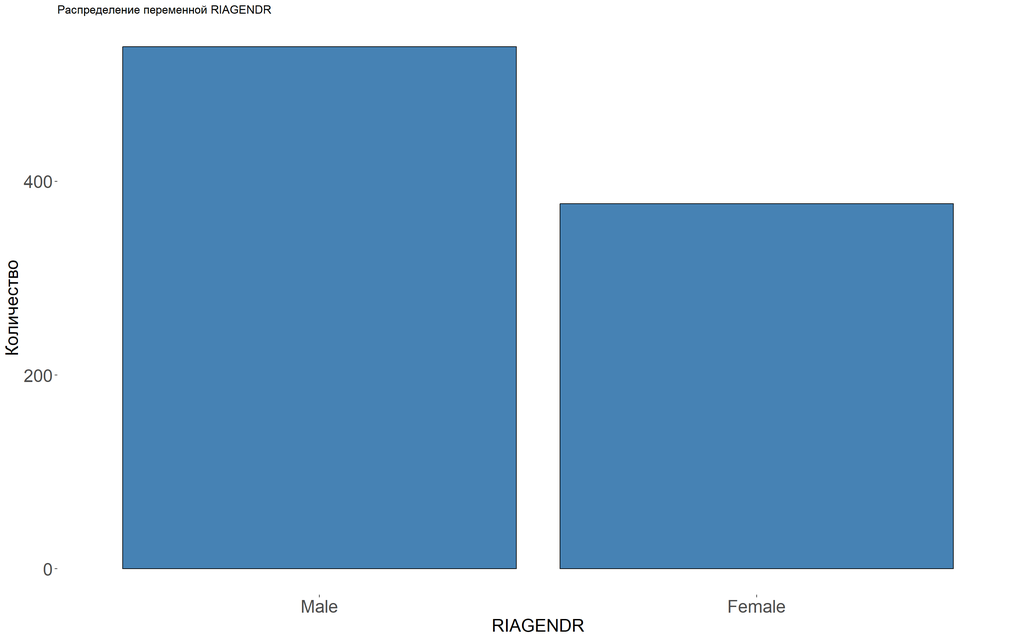

```r
# Функция для построения bar plot
plot_bar <- function(data, var) {
  ggplot(data, aes(x = !!sym(var))) +
    geom_bar(fill = "steelblue", color = "black") +
    labs(title = paste("Распределение переменной", var),
         x = var, y = "Количество") +
    theme_custom()
}

# Построение графиков для каждой категориальной переменной
plot_bar(GH, "RIAGENDR")
```

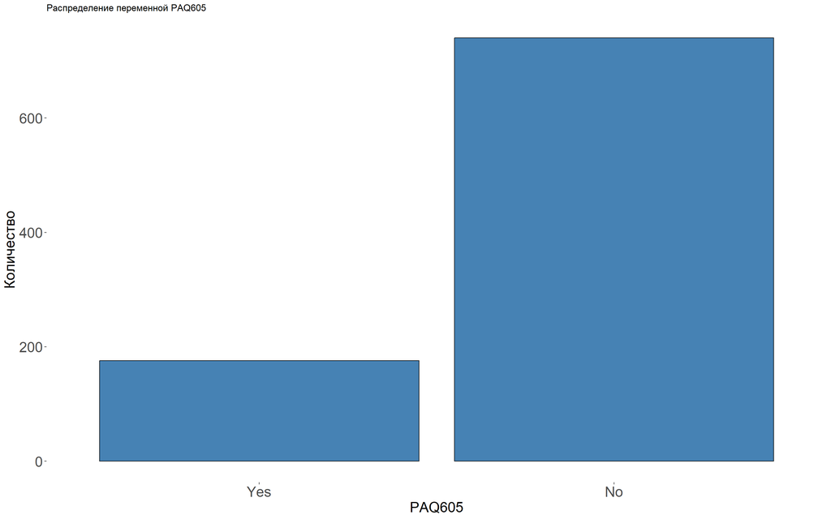

```r
plot_bar(GH, "PAQ605")
```

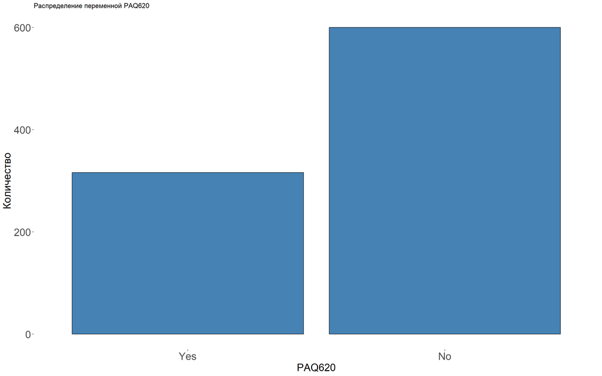

```r
plot_bar(GH, "PAQ620")
```

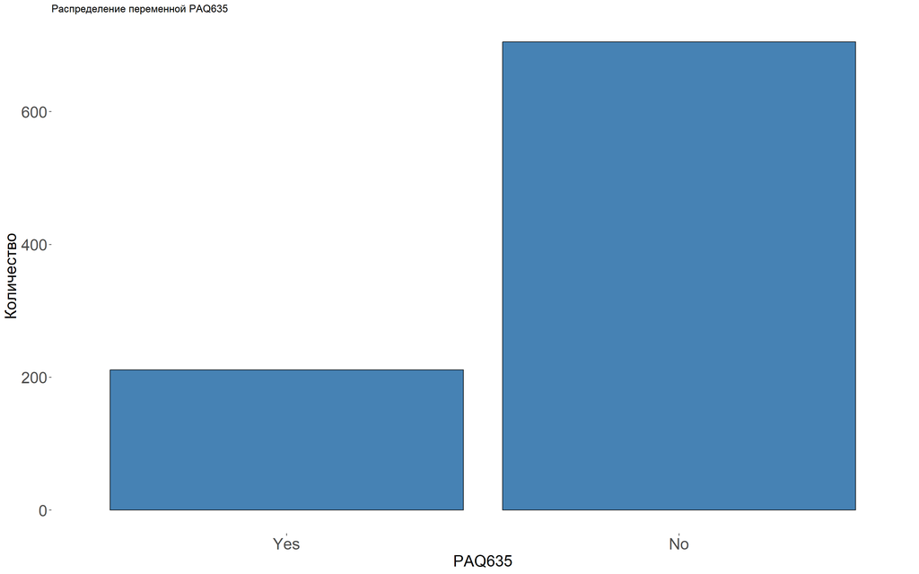

```r
plot_bar(GH, "PAQ635")
```

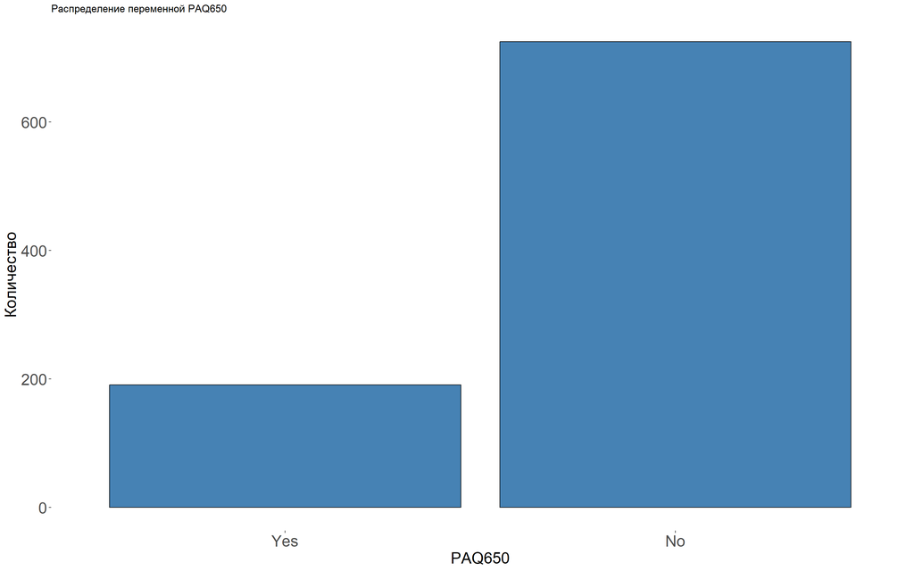

```r
plot_bar(GH, "PAQ650")
```

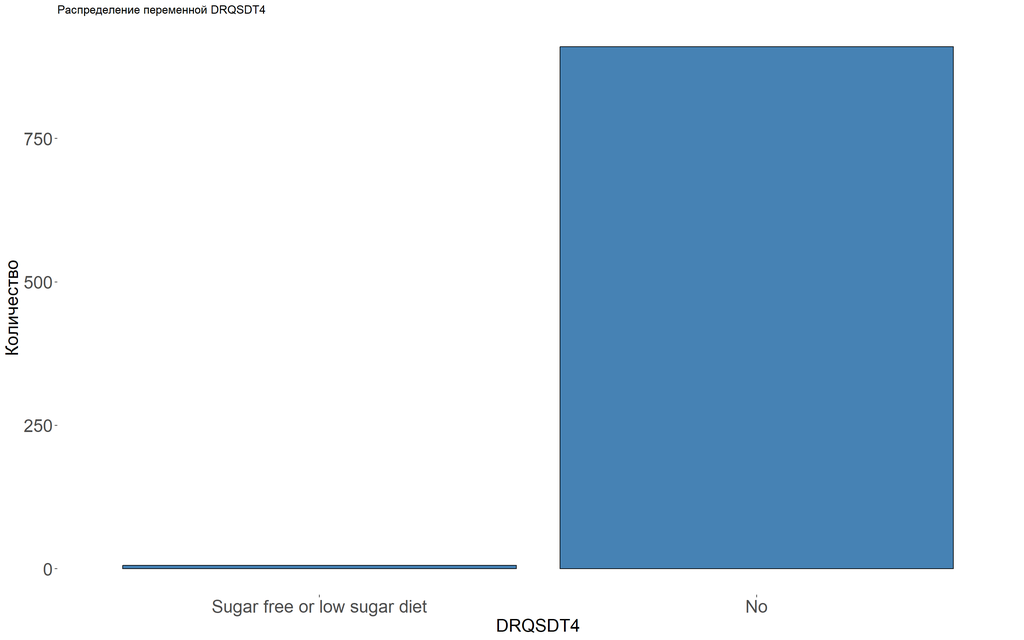

```r
plot_bar(GH, "DRQSDT4")
```

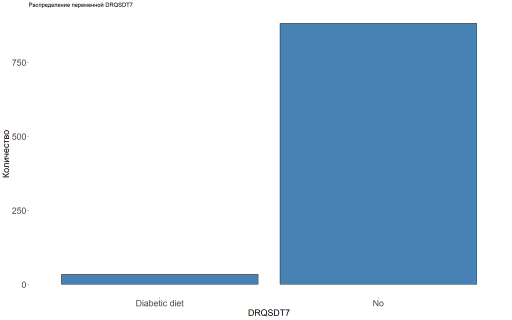

```r
plot_bar(GH, "DRQSDT7")
```

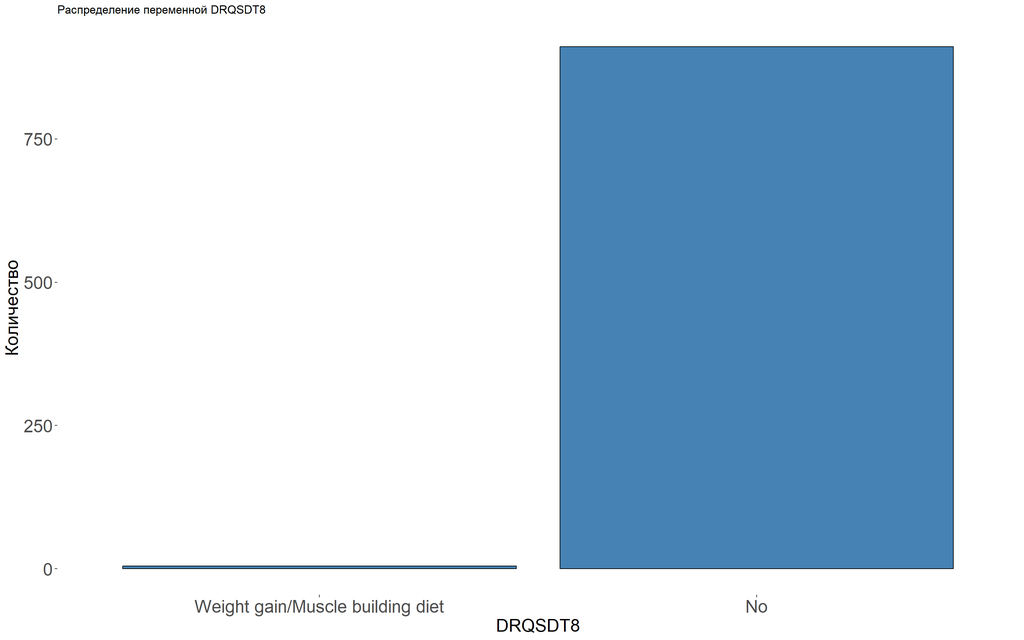

```r
plot_bar(GH, "DRQSDT8")
```

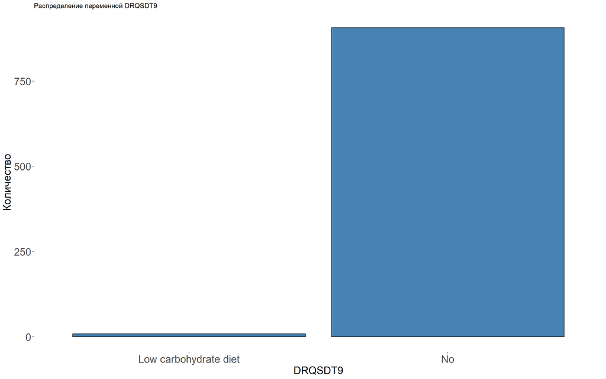

```r
plot_bar(GH, "DRQSDT9")
```

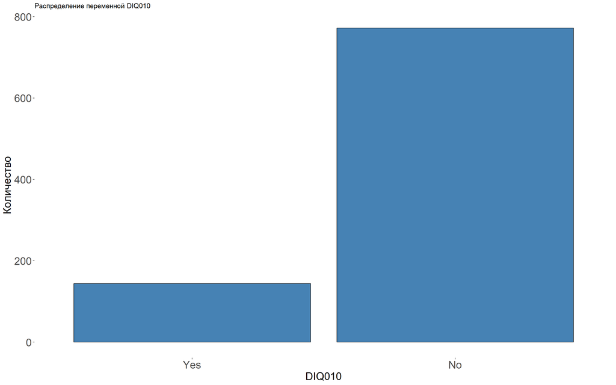

```r
plot_bar(GH, "DIQ010")
```

# Зависимость LBXGH от категориальных переменных

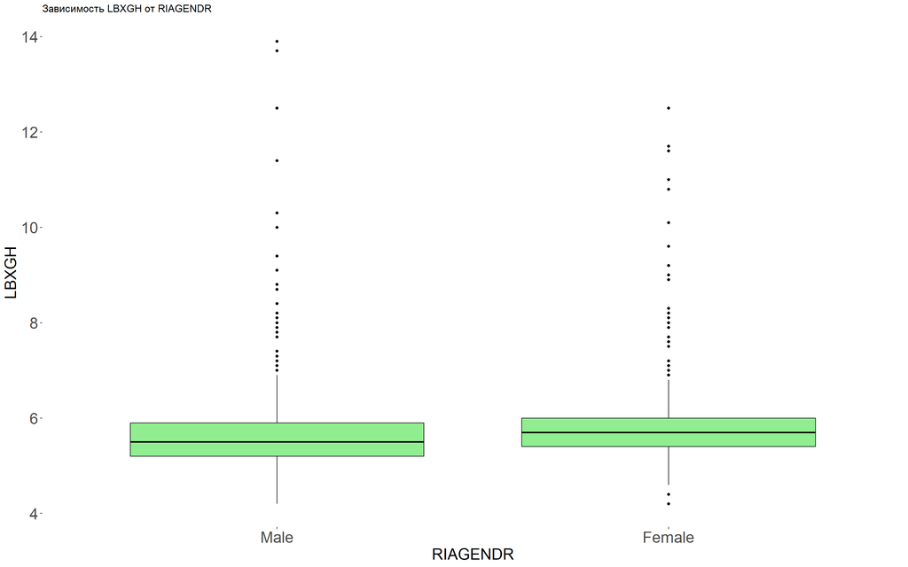

```r
# Функция для построения box plot
plot_box <- function(data, x_var) {
  ggplot(data, aes(x = !!sym(x_var), y = LBXGH)) +
    geom_boxplot(fill = "lightgreen", color = "black") +
    labs(title = paste("Зависимость LBXGH от", x_var),
         x = x_var, y = "LBXGH") +
    theme_custom()
}

# Построение графиков для каждой категориальной переменной
plot_box(GH, "RIAGENDR")
```

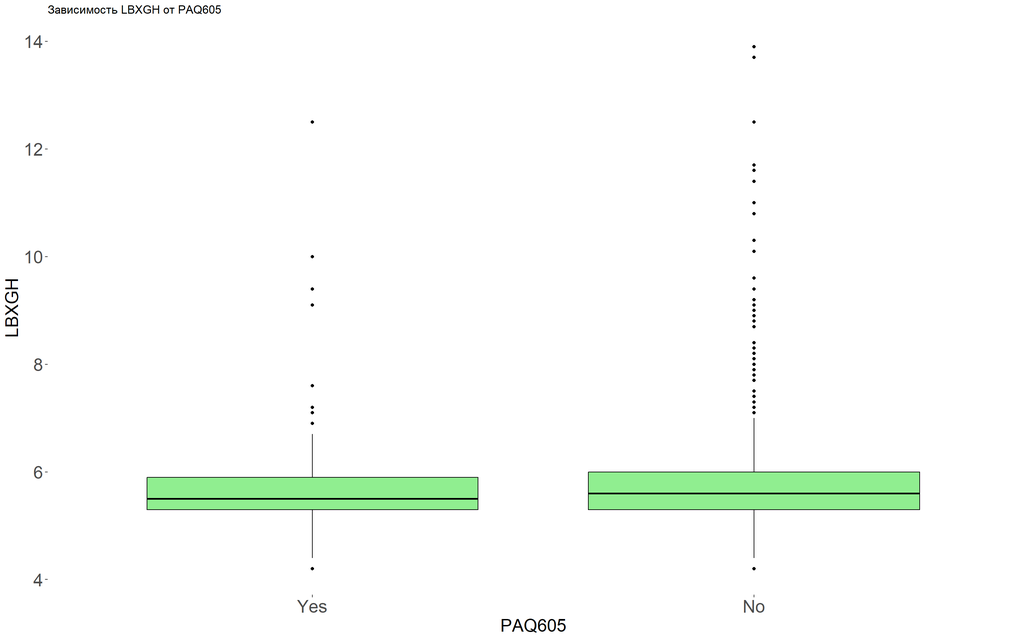

```r
plot_box(GH, "PAQ605")
```

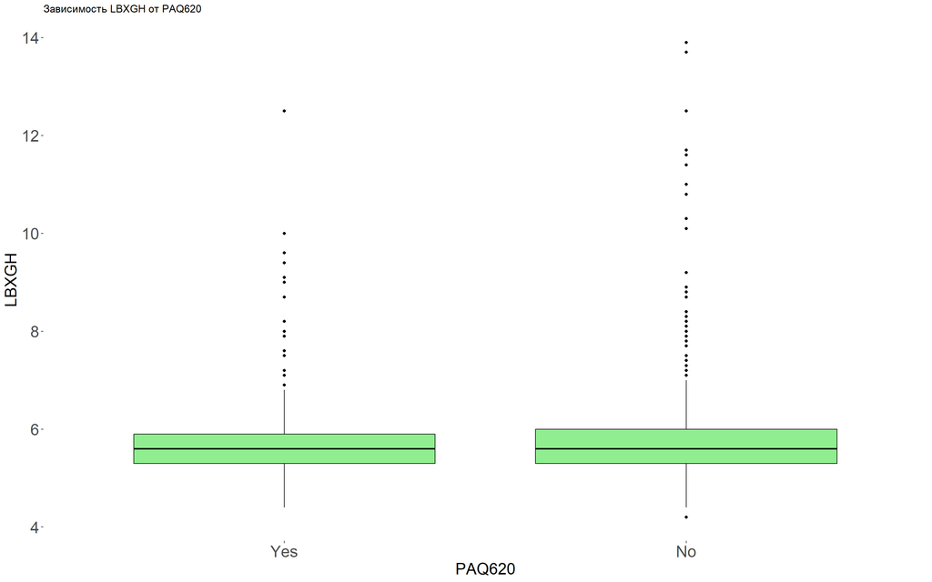

```r
plot_box(GH, "PAQ620")
```

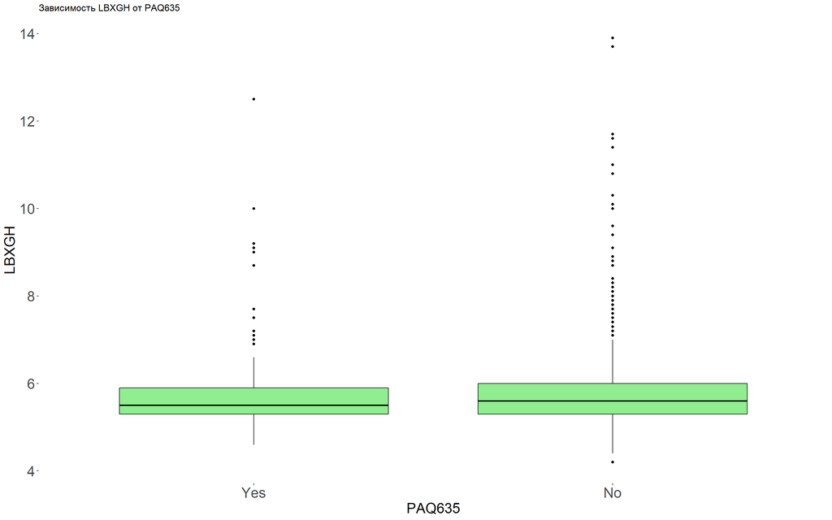

```r
plot_box(GH, "PAQ635")
```

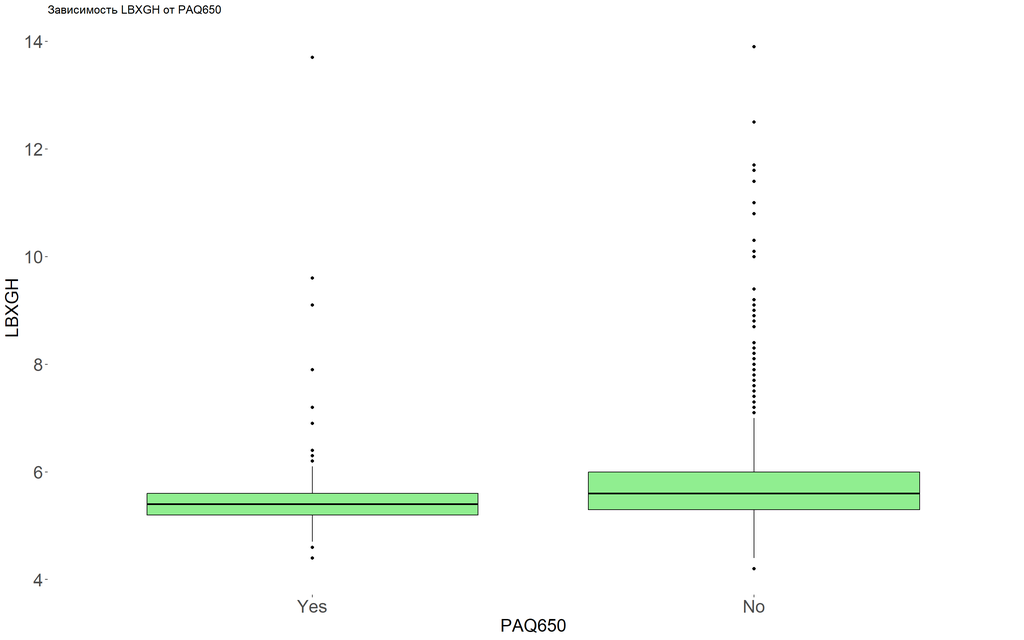

```r
plot_box(GH, "PAQ650")
```

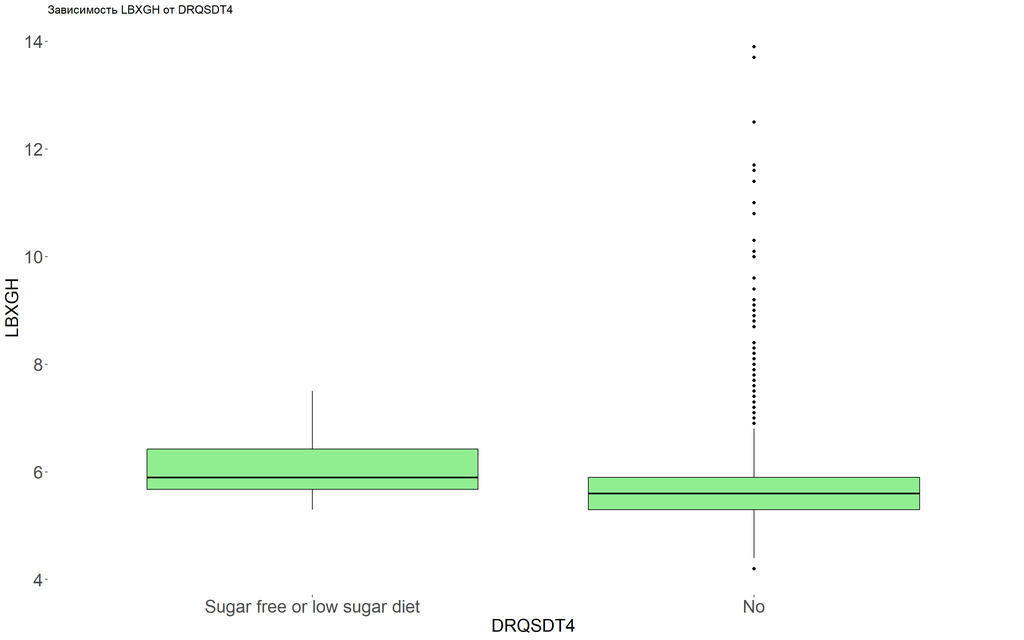

```r
plot_box(GH, "DRQSDT4")
```

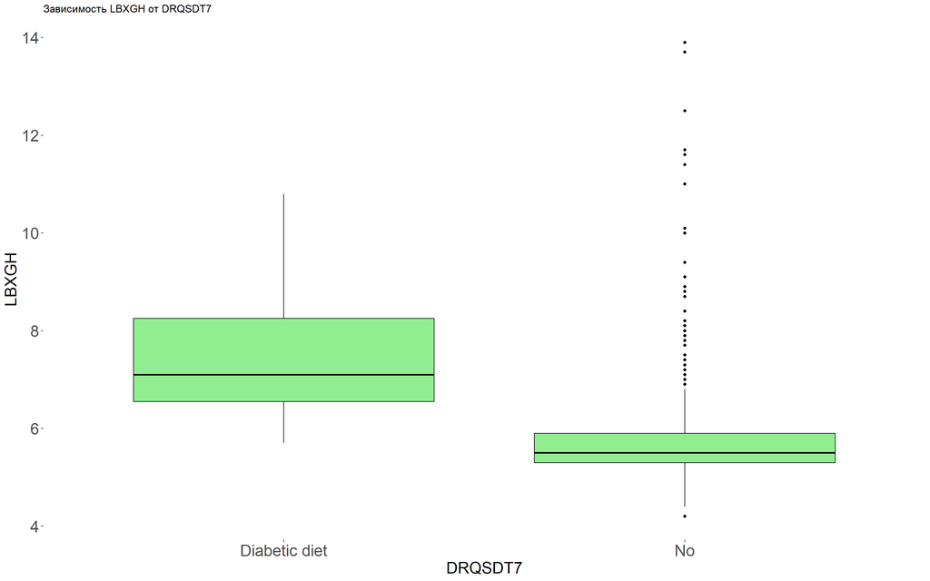

```r
plot_box(GH, "DRQSDT7")
```

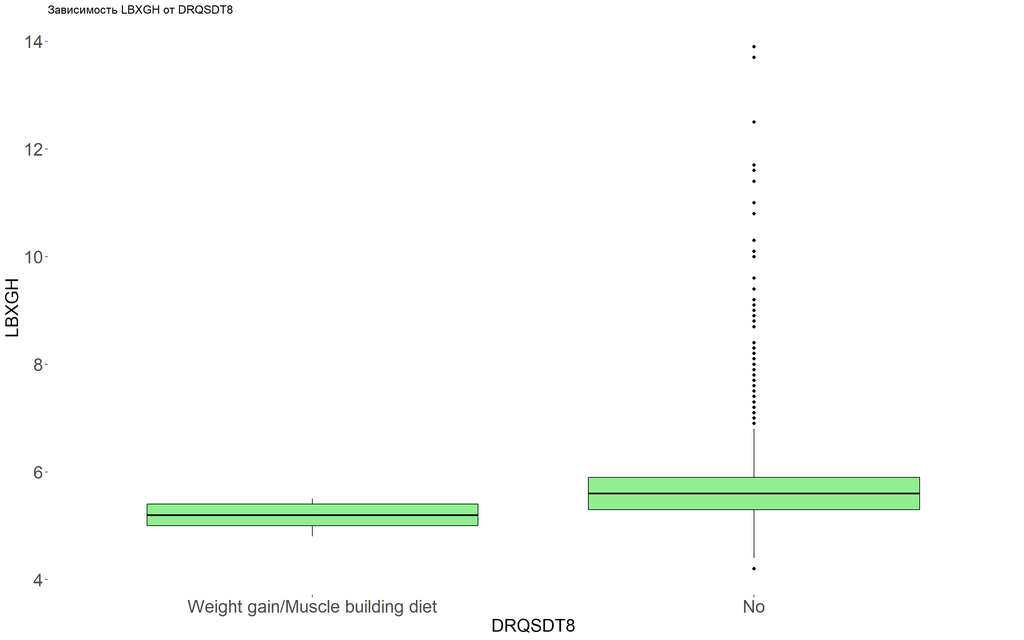

```r
plot_box(GH, "DRQSDT8")
```

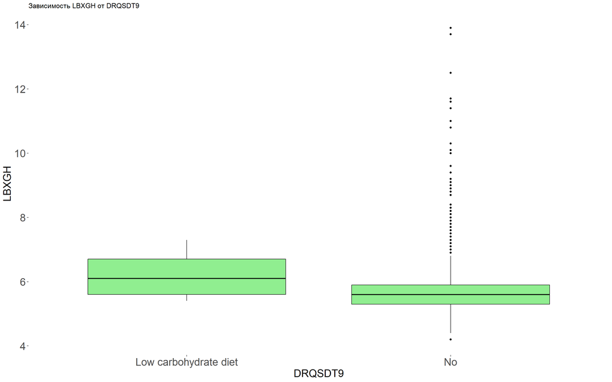

```r
plot_box(GH, "DRQSDT9")
```

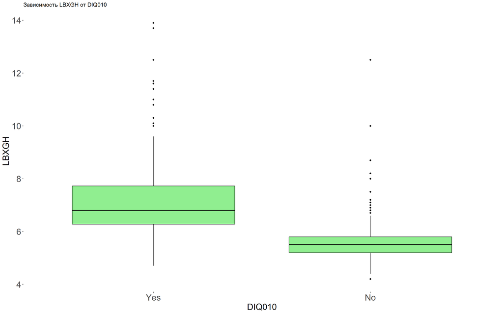

```r
plot_box(GH, "DIQ010")
```

```r
str(GH)
```

```
## tibble [916 × 23] (S3: tbl_df/tbl/data.frame)
##  $ SEQN    : num [1:916] 81603 81783 80825 74081 83352 ...
##  $ RIAGENDR: Factor w/ 2 levels "Male","Female": 2 1 1 1 1 1 1 2 1 2 ...
##  $ RIDAGEYR: num [1:916] 76 44 30 80 20 52 22 45 25 62 ...
##  $ LBXGH   : num [1:916] 6.2 5.6 5.2 5.8 5.2 5.3 5 6.4 4.8 5.6 ...
##  $ PAQ610  : num [1:916] 0 6 5 0 0 0 3 0 0 0 ...
##  $ PAD615  : num [1:916] 0 60 360 0 0 0 240 0 0 0 ...
##  $ PAQ605  : Factor w/ 2 levels "Yes","No": 2 1 1 2 2 2 1 2 2 2 ...
##  $ PAQ620  : Factor w/ 2 levels "Yes","No": 2 1 2 1 1 2 1 2 2 2 ...
##  $ PAQ625  : num [1:916] 0 3 0 5 2 0 5 0 0 0 ...
##  $ PAD630  : num [1:916] 0 90 0 240 60 0 240 0 0 0 ...
##  $ PAQ635  : Factor w/ 2 levels "Yes","No": 2 2 2 2 1 2 2 2 2 1 ...
##  $ PAQ640  : num [1:916] 0 0 0 0 5 0 0 0 0 5 ...
##  $ PAD645  : num [1:916] 0 0 0 0 120 0 0 0 0 10 ...
##  $ PAQ650  : Factor w/ 2 levels "Yes","No": 2 1 2 2 2 2 1 2 2 2 ...
##  $ PAQ655  : num [1:916] 0 6 0 0 0 0 3 0 0 0 ...
##  $ PAD660  : num [1:916] 0 45 0 0 0 0 45 0 0 0 ...
##  $ BMXBMI  : num [1:916] 27.7 24.7 26.1 30.2 28.1 23.5 30.6 28.3 20.8 23.6 ...
##  $ DRQSDT4 : Factor w/ 2 levels "Sugar free or low sugar diet",..: 2 2 2 2 2 2 2 2 2 2 ...
##  $ DRQSDT7 : Factor w/ 2 levels "Diabetic diet",..: 2 2 2 2 2 2 2 1 2 2 ...
##  $ DRQSDT8 : Factor w/ 2 levels "Weight gain/Muscle building diet",..: 2 2 2 2 2 2 2 2 2 2 ...
##  $ DRQSDT9 : Factor w/ 2 levels "Low carbohydrate diet",..: 2 2 2 2 2 2 2 2 2 2 ...
##  $ DIQ010  : Factor w/ 2 levels "Yes","No": 1 2 2 2 2 2 2 1 2 2 ...
##  $ DR1TTFAT: num [1:916] 69.7 123.6 67 161.1 99.3 ...
```

# Описательные статистики с разбивкой по полу

```r
data %>%
  select(SEQN,
         LBXGH,
         RIDAGEYR,
         LBXGH,
         PAD615,
         PAD630,
         PAQ640,
         PAD645,
         PAQ655,
         BMXBMI,
         DR1TTFAT,
         RIAGENDR) %>%
  tbl_summary(by = RIAGENDR) %>%
  add_p()
```

| **Characteristic** | **1** N = 539<sup>1</sup> | **2** N = 377<sup>1</sup> | **p-value**<sup>2</sup> |
| --- | --- | --- | --- |
| SEQN | 78,640 (76,041, 81,213) | 78,979 (76,465, 81,497) | 0.3 |
| LBXGH | 5.50 (5.20, 5.90) | 5.70 (5.40, 6.00) | <0.001 |
| RIDAGEYR | 49 (34, 64) | 61 (52, 71) | <0.001 |
| PAD615 | 0 (0, 15) | 0 (0, 0) | <0.001 |
| PAD630 | 0 (0, 60) | 0 (0, 20) | 0.003 |
| PAQ640 |  |  |  |
| 0 | 394 (73%) | 311 (82%) |  |
| 1 | 6 (1.1%) | 6 (1.6%) |  |
| 2 | 15 (2.8%) | 6 (1.6%) |  |
| 3 | 18 (3.3%) | 11 (2.9%) |  |
| 4 | 11 (2.0%) | 6 (1.6%) |  |
| 5 | 40 (7.4%) | 19 (5.0%) |  |
| 6 | 4 (0.7%) | 4 (1.1%) |  |
| 7 | 51 (9.5%) | 14 (3.7%) |  |
| PAD645 | 0 (0, 10) | 0 (0, 0) | <0.001 |
| PAQ655 |  |  |  |
| 0 | 395 (73%) | 330 (88%) |  |
| 1 | 20 (3.7%) | 2 (0.5%) |  |
| 2 | 28 (5.2%) | 13 (3.4%) |  |
| 3 | 35 (6.5%) | 11 (2.9%) |  |
| 4 | 22 (4.1%) | 7 (1.9%) |  |
| 5 | 21 (3.9%) | 8 (2.1%) |  |
| 6 | 11 (2.0%) | 3 (0.8%) |  |
| 7 | 7 (1.3%) | 3 (0.8%) |  |
| BMXBMI | 28 (25, 32) | 29 (25, 34) | 0.10 |
| DR1TTFAT | 84 (60, 118) | 61 (40, 84) | <0.001 |

<sup>1</sup> Median (Q1, Q3); n (%)  
<sup>2</sup> Wilcoxon rank sum test

# Визуализация распределения LBXGH (гликированный гемоглобин)

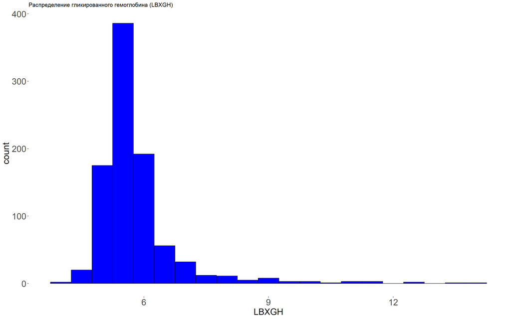

```r
# Визуализация распределения LBXGH (гликированный гемоглобин)
ggplot(GH, aes(x = LBXGH)) +
  geom_histogram(binwidth = 0.5, fill = "blue", color = "black") +
  labs(title = "Распределение гликированного гемоглобина (LBXGH)") +
  theme_custom()
```

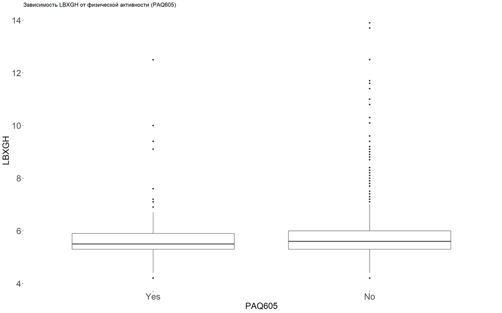

```r
# Визуализация зависимости LBXGH от физической активности (например, PAQ605)
ggplot(GH, aes(x = PAQ605, y = LBXGH)) +
  geom_boxplot() +
  labs(title = "Зависимость LBXGH от физической активности (PAQ605)")+
  theme_custom()
```

# 4.1.1 Матрица коэффициента корреляции Пирсона

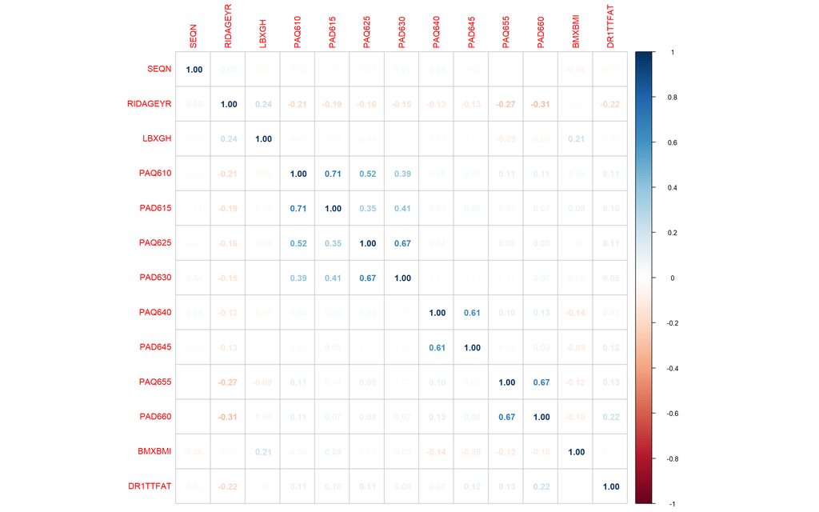

```r
# Выбираем только числовые переменные
data_numeric <- GH %>% select_if(is.numeric)

# Вычисляем корреляцию для числовых переменных
data_cor <- cor(data_numeric, use = "complete.obs")

corrplot(data_cor, method = 'number')
```

# 4.1.2 Матрица коэффициента корреляции Пирсона в другом исполнении

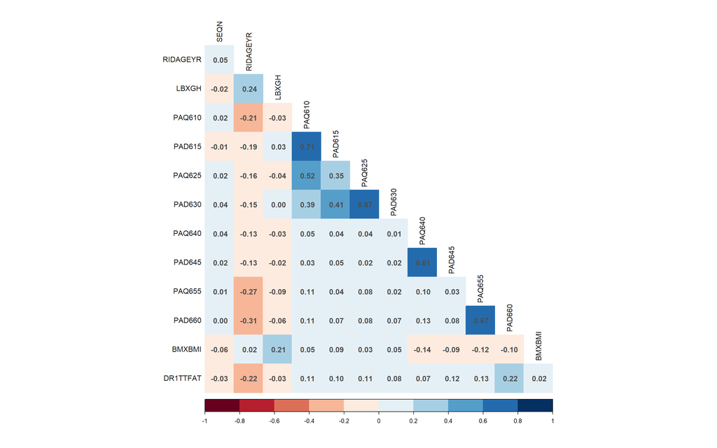

```r
corrplot(data_cor, method = "color", type = "lower",
         addCoef.col = "grey30", diag = FALSE,
         cl.pos = "b", tl.col = "grey10",
         col = COL2('RdBu', 10))
```

# Матрица корреляции с использованием графика сети

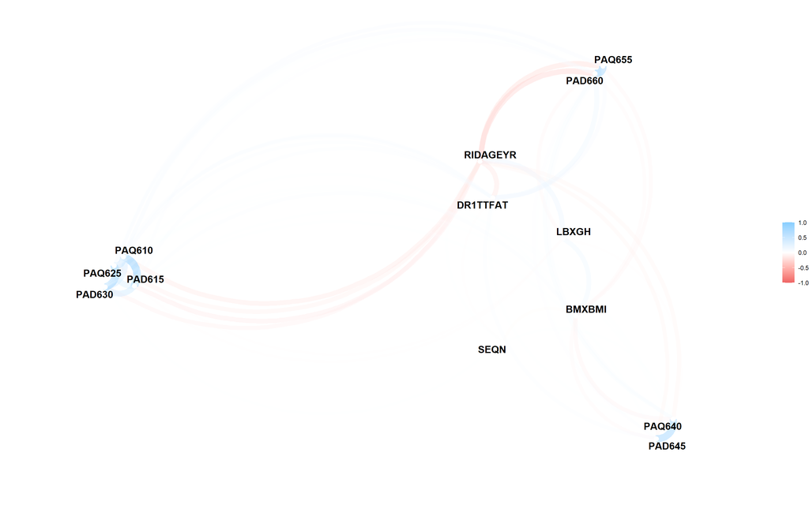

```r
data_cor %>%
  network_plot(min_cor = .0)
```

#Оценка общего (total) эффекта физической активности построим две модели:

Модель 1: Зависимость LBXGH от физической активности (PAQ605) без ковариат.

Модель 2: Зависимость LBXGH от физической активности с ковариатами (например, возраст RIDAGEYR, пол RIAGENDR, ИМТ BMXBMI).

```r
# Модель 1: Без ковариат
model_total <- lm(LBXGH ~ PAQ605, data = GH)
summary(model_total)
```

```
##
## Call:
## lm(formula = LBXGH ~ PAQ605, data = GH)
##
## Residuals:
##     Min      1Q  Median      3Q     Max
## -1.6200 -0.5200 -0.2200  0.1705  8.0800
##
## Coefficients:
##             Estimate Std. Error t value Pr(>|t|)
## (Intercept)  5.72955    0.07801  73.442   <2e-16 ***
## PAQ605No     0.09045    0.08680   1.042    0.298
## ---
## Signif. codes:  0 '***' 0.001 '**' 0.01 '*' 0.05 '.' 0.1 ' ' 1
##
## Residual standard error: 1.035 on 914 degrees of freedom
## Multiple R-squared:  0.001187,   Adjusted R-squared:  9.401e-05
## F-statistic: 1.086 on 1 and 914 DF,  p-value: 0.2976
```

```r
# Модель 2: С ковариатами
model_total_cov <- lm(LBXGH ~ PAQ605 + RIDAGEYR + RIAGENDR + BMXBMI, data = GH)
summary(model_total_cov)
```

```
##
## Call:
## lm(formula = LBXGH ~ PAQ605 + RIDAGEYR + RIAGENDR + BMXBMI, data = GH)
##
## Residuals:
##     Min      1Q  Median      3Q     Max
## -1.9886 -0.4719 -0.1694  0.1361  8.0637
##
## Coefficients:
##                 Estimate Std. Error t value Pr(>|t|)
## (Intercept)     4.018164   0.189436  21.211  < 2e-16 ***
## PAQ605No       -0.004695   0.085423  -0.055    0.956
## RIDAGEYR        0.015769   0.002152   7.327 5.19e-13 ***
## RIAGENDRFemale -0.091058   0.071910  -1.266    0.206
## BMXBMI          0.032777   0.004850   6.758 2.49e-11 ***
## ---
## Signif. codes:  0 '***' 0.001 '**' 0.01 '*' 0.05 '.' 0.1 ' ' 1
##
## Residual standard error: 0.9827 on 911 degrees of freedom
## Multiple R-squared:  0.1024, Adjusted R-squared:  0.09851
## F-statistic:    26 on 4 and 911 DF,  p-value: < 2.2e-16
```

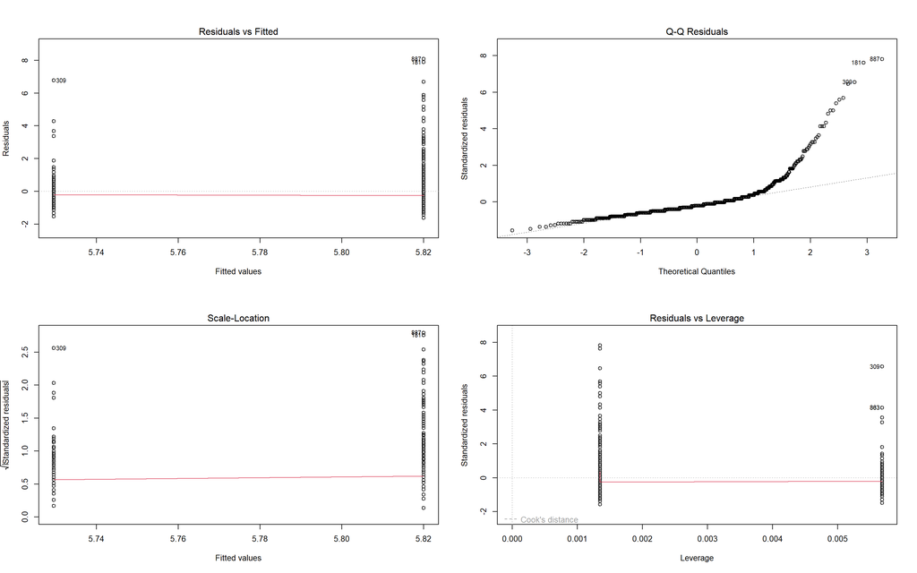

```r
# Диагностика моделей
par(mfrow = c(2, 2))
plot(model_total)  # Графики остатков для модели 1
```

```r
plot(model_total_cov)  # Графики остатков для модели 2
```

[output not shown]

Модель 1

Физическая активность (PAQ605) сама по себе не оказывает значимого влияния на уровень гликированного гемоглобина (LBXGH).

Модель 2 Физическая активность (PAQ605) не оказывает значимого влияния на LBXGH после учета ковариат Возраст значимо влияет на LBXGH: с увеличением возраста на 1 год уровень LBXGH увеличивается на 0,0158 единиц. стат значимо (5.19e-13). Пол не оказывает значимого влияния на LBXGH С увеличением ИМТ на 1 единицу уровень LBXGH увеличивается на 0,0328 единиц.стат значимо (2.49e-11)